# Social_media_Logistic_Regression

Deviprasad Saka

2024-04-18

```r
library(ggplot2)
library(cowplot)
#library(regclass)
library(caret)
library(e1071)
library(pROC)
data <- read.csv("D:/Multivariate Analysis/Assignment-8/social_media_final.csv", row.names=1)
data
```

```
##         Instagram_Usage LinkedIn_Usage Snapchat_Usage Twitter_Usage
## masinl             3.50           4.00           1.00          5.00
## peace              7.44           5.12           3.41         12.00
## Patty              3.46           7.00          12.32          0.00
## Bunny              5.23           5.19           1.18          0.00
## tl868              0.00          12.35           0.00         12.40
## drphy              2.20           7.00          12.28          0.00
## trave              5.22           4.00           0.00          0.00
## 19!@s              7.00           4.00           3.00          0.00
## yh2020             8.39          10.00           3.50          0.00
## ds2134            12.10          12.00           0.00          0.00
## ki567              4.35           2.08          12.25          2.25
## ak2001             3.20           2.30          12.20          2.50
## Harvey             5.30           1.52           0.62          0.00
## hahah              6.00           3.00           1.00          1.00
## AKIRA              4.39           3.45           1.25          0.00
## vp1234             7.00           5.00          12.25         12.16
## sss32              9.48          12.48           0.00          0.00
## MVA37@S            6.48           1.55           1.52          0.00
## 2134               5.40           3.55           0.00          0.00
## 15801              3.01           3.57           7.19          0.00
## Baiqi             12.20          12.31           0.00          0.00
##         Whatsapp_Usage Youtube_Usage   OTT Reddit Trouble_falling_asleep
## masinl            1.00          2.50 14.50   2.50                      0
## peace             4.11          4.15 12.00  12.00                      1
## Patty             9.50          1.51  2.00   0.00                      0
## Bunny             5.18          2.00  2.00   0.00                      0
## tl868             3.00          3.30  2.00   1.00                      1
## drphy            12.00          7.00  3.00   0.00                      0
## trave             6.00          3.00  0.00   0.00                      0
## 19!@s            10.00          2.00  3.00   0.00                      1
## yh2020            6.09          4.00  3.00   0.00                      0
## ds2134            1.00          3.00  0.00   0.00                      0
## ki567             1.00          1.00 12.00   0.00                      1
## ak2001            3.40          2.30  1.30   0.00                      0
## Harvey            4.02          0.54  0.51   0.01                      1
## hahah             3.25          2.30  1.00   0.00                      0
## AKIRA             6.30          3.08  1.55   7.00                      0
## vp1234            5.00          5.00  1.00  12.30                      1
## sss32             1.21          3.32  1.41   0.00                      0
```

[output cut: 11 more lines]

```
## trave                   1                          1
## 19!@s                   1                          1
## yh2020                  1                          0
## ds2134                  0                          0
## ki567                   1                          0
## ak2001                  1                          0
## Harvey                  1                          1
## hahah                   1                          0
## AKIRA                   1                          0
## vp1234                  1                          1
## sss32                   1                          0
## MVA37@S                 1                          1
## 2134                    1                          0
## 15801                   1                          0
## Baiqi                   1                          1
```

```r
head(data)
```

```
##        Instagram_Usage LinkedIn_Usage Snapchat_Usage Twitter_Usage
## masinl            3.50           4.00           1.00           5.0
## peace             7.44           5.12           3.41          12.0
## Patty             3.46           7.00          12.32           0.0
## Bunny             5.23           5.19           1.18           0.0
## tl868             0.00          12.35           0.00          12.4
## drphy             2.20           7.00          12.28           0.0
##        Whatsapp_Usage Youtube_Usage  OTT Reddit Trouble_falling_asleep
## masinl           1.00          2.50 14.5    2.5                      0
## peace            4.11          4.15 12.0   12.0                      1
## Patty            9.50          1.51  2.0    0.0                      0
## Bunny            5.18          2.00  2.0    0.0                      0
## tl868            3.00          3.30  2.0    1.0                      1
## drphy           12.00          7.00  3.0    0.0                      0
##        Mood.Productivity Tired.waking.up.in.morning
## masinl                 1                          0
## peace                  1                          0
## Patty                  1                          0
## Bunny                  1                          0
## tl868                  1                          1
## drphy                  1                          0
```

```r
xtabs(~ Tired.waking.up.in.morning + Instagram_Usage, data=data)
```

```
##                           Instagram_Usage
## Tired.waking.up.in.morning 0 2.2 3.01 3.2 3.46 3.5 4.35 4.39 5.22 5.23 5.3 5.4
##                          0 0   1    1   1    1   1    1    1    0    1   0   1
##                          1 1   0    0   0    0   0    0    0    1    0   1   0
##                           Instagram_Usage
## Tired.waking.up.in.morning 6 6.48 7 7.44 8.39 9.48 12.1 12.2
##                          0 1    0 0    1    1    1    1    0
##                          1 0    1 2    0    0    0    0    1
```

```r
xtabs(~ Tired.waking.up.in.morning + LinkedIn_Usage, data=data)
```

```
##                           LinkedIn_Usage
## Tired.waking.up.in.morning 1.52 1.55 2.08 2.3 3 3.45 3.55 3.57 4 5 5.12 5.19 7
##                          0    0    0    1   1 1    1    1    1 1 0    1    1 2
##                          1    1    1    0   0 0    0    0    0 2 1    0    0 0
##                           LinkedIn_Usage
## Tired.waking.up.in.morning 10 12 12.31 12.35 12.48
##                          0  1  1     0     0     1
##                          1  0  0     1     1     0
```

```r
xtabs(~ Tired.waking.up.in.morning + Snapchat_Usage, data=data)
```

```
##                           Snapchat_Usage
## Tired.waking.up.in.morning 0 0.62 1 1.18 1.25 1.52 3 3.41 3.5 7.19 12.2 12.25
##                          0 3    0 2    1    1    0 0    1   1    1    1     1
##                          1 3    1 0    0    0    1 1    0   0    0    0     1
##                           Snapchat_Usage
## Tired.waking.up.in.morning 12.28 12.32
##                          0     1     1
##                          1     0     0
```

```r
xtabs(~ Tired.waking.up.in.morning + Twitter_Usage, data=data)
```

```
##                           Twitter_Usage
## Tired.waking.up.in.morning 0 1 2.25 2.5 5 12 12.16 12.4
##                          0 9 1    1   1 1  1     0    0
##                          1 5 0    0   0 0  0     1    1
```

```r
xtabs(~ Tired.waking.up.in.morning + Youtube_Usage, data=data)
```

```
##                           Youtube_Usage
## Tired.waking.up.in.morning 0 0.54 1 1.51 2 2.3 2.5 3 3.08 3.3 3.32 4 4.15 5
##                          0 0    0 1    1 1   2   1 1    1   0    1 1    1 0
##                          1 1    1 0    0 1   0   0 1    0   1    0 0    0 1
##                           Youtube_Usage
## Tired.waking.up.in.morning 5.09 5.1 7 12.48
##                          0    1   1 1     0
##                          1    0   0 0     1
```

```r
xtabs(~ Tired.waking.up.in.morning + OTT, data=data)
```

```
##                           OTT
## Tired.waking.up.in.morning 0 0.51 1 1.3 1.41 1.55 2 2.28 3 10 12 14.5
##                          0 2    0 1   1    1    1 2    0 2  1  2    1
##                          1 2    1 1   0    0    0 1    1 1  0  0    0
```

```r
xtabs(~ Tired.waking.up.in.morning + Reddit, data=data)
```

```
##                           Reddit
## Tired.waking.up.in.morning  0 0.01  1 2.5  7 12 12.3
##                          0 11    0  0   1  1  1    0
##                          1  4    1  1   0  0  0    1
```

Q1: Model Developement

```r
logistic_simple <- glm(Tired.waking.up.in.morning ~ Instagram_Usage, data=data, family="binomial")
summary(logistic_simple)
```

```
##
## Call:
## glm(formula = Tired.waking.up.in.morning ~ Instagram_Usage, family = "binomial",
##     data = data)
##
## Coefficients:
##                 Estimate Std. Error z value Pr(>|z|)
## (Intercept)     -1.08475    1.03848  -1.045    0.296
## Instagram_Usage  0.06669    0.15580   0.428    0.669
##
## (Dispersion parameter for binomial family taken to be 1)
##
##     Null deviance: 26.734  on 20  degrees of freedom
## Residual deviance: 26.550  on 19  degrees of freedom
## AIC: 30.55
##
## Number of Fisher Scoring iterations: 4
```

The logistic regression model suggests that Instagram usage is not a significant predictor of feeling tired upon waking up in the morning (p = 0.669). The intercept indicates a baseline tiredness level of approximately -1.08475 when Instagram usage is zero, with a small increase in tiredness log-odds (0.06669) for each unit increase in Instagram usage. The model’s fit is modest, with slightly lower residual deviance compared to null deviance, and an AIC of 30.55.

```r
Less_hours.log.odds <- -1.08475
Less_hours.log.odds
```

```
## [1] -1.08475
```

```r
more_hours.log.odds.ratio <- 0.06669
more_hours.log.odds.ratio
```

```
## [1] 0.06669
```

```r
predicted.data <- data.frame(probability.of.hd=logistic_simple$fitted.values, Instagram=data$Instagram_Usage)
predicted.data
```

```
##         probability.of.hd Instagram
## masinl          0.2991545      3.50
## peace           0.3569661      7.44
## Patty           0.2985955      3.46
## Bunny           0.3238908      5.23
## tl868           0.2526076      0.00
## drphy           0.2812988      2.20
## trave           0.3237448      5.22
## 19!@s           0.3502589      7.00
## yh2020          0.3716376      8.39
## ds2134          0.4310014     12.10
## ki567           0.3111737      4.35
## ak2001          0.2949766      3.20
## Harvey          0.3249140      5.30
## hahah           0.3352366      6.00
## AKIRA           0.3117458      4.39
## vp1234          0.3502589      7.00
## sss32           0.3887659      9.48
## MVA37@S         0.3424080      6.48
## 2134            0.3263786      5.40
## 15801           0.2923482      3.01
## Baiqi           0.4326377     12.20
```

```r
xtabs(~ probability.of.hd + Instagram, data=predicted.data)
```

```
##                    Instagram
## probability.of.hd   0 2.2 3.01 3.2 3.46 3.5 4.35 4.39 5.22 5.23 5.3 5.4 6 6.48
##   0.252607618576425 1   0    0   0    0   0    0    0    0    0   0   0 0    0
##   0.281298815276842 0   1    0   0    0   0    0    0    0    0   0   0 0    0
##   0.292348166093942 0   0    1   0    0   0    0    0    0    0   0   0 0    0
##   0.294976574507887 0   0    0   1    0   0    0    0    0    0   0   0 0    0
##   0.29859551160095  0   0    0   0    1   0    0    0    0    0   0   0 0    0
##   0.29915452955234  0   0    0   0    0   1    0    0    0    0   0   0 0    0
##   0.311173661163833 0   0    0   0    0   0    1    0    0    0   0   0 0    0
##   0.311745761144012 0   0    0   0    0   0    0    1    0    0   0   0 0    0
##   0.323744780882077 0   0    0   0    0   0    0    0    1    0   0   0 0    0
##   0.323890811943981 0   0    0   0    0   0    0    0    0    1   0   0 0    0
##   0.324913988842855 0   0    0   0    0   0    0    0    0    0   1   0 0    0
##   0.326378572317326 0   0    0   0    0   0    0    0    0    0   0   1 0    0
##   0.33523664151087  0   0    0   0    0   0    0    0    0    0   0   0 1    0
##   0.342407977386444 0   0    0   0    0   0    0    0    0    0   0   0 0    1
##   0.350258903178298 0   0    0   0    0   0    0    0    0    0   0   0 0    0
##   0.356966149465568 0   0    0   0    0   0    0    0    0    0   0   0 0    0
##   0.371637577621657 0   0    0   0    0   0    0    0    0    0   0   0 0    0
##   0.388765934826472 0   0    0   0    0   0    0    0    0    0   0   0 0    0
##   0.431001399100189 0   0    0   0    0   0    0    0    0    0   0   0 0    0
##   0.432637721832888 0   0    0   0    0   0    0    0    0    0   0   0 0    0
##                    Instagram
## probability.of.hd   7 7.44 8.39 9.48 12.1 12.2
##   0.252607618576425 0    0    0    0    0    0
##   0.281298815276842 0    0    0    0    0    0
##   0.292348166093942 0    0    0    0    0    0
##   0.294976574507887 0    0    0    0    0    0
##   0.29859551160095  0    0    0    0    0    0
##   0.29915452955234  0    0    0    0    0    0
##   0.311173661163833 0    0    0    0    0    0
##   0.311745761144012 0    0    0    0    0    0
##   0.323744780882077 0    0    0    0    0    0
##   0.323890811943981 0    0    0    0    0    0
##   0.324913988842855 0    0    0    0    0    0
##   0.326378572317326 0    0    0    0    0    0
##   0.33523664151087  0    0    0    0    0    0
##   0.342407977386444 0    0    0    0    0    0
##   0.350258903178298 2    0    0    0    0    0
##   0.356966149465568 0    1    0    0    0    0
##   0.371637577621657 0    0    1    0    0    0
##   0.388765934826472 0    0    0    1    0    0
##   0.431001399100189 0    0    0    0    1    0
##   0.432637721832888 0    0    0    0    0    1
```

Q2.Model Acceptance

```r
logistic <- glm(Tired.waking.up.in.morning ~ ., data=data, family="binomial")
summary(logistic)
```

```
##
## Call:
## glm(formula = Tired.waking.up.in.morning ~ ., family = "binomial",
##     data = data)
##
## Coefficients:
##                          Estimate Std. Error z value Pr(>|z|)
## (Intercept)               -516.38  910824.86  -0.001    1.000
## Instagram_Usage             73.36   80092.10   0.001    0.999
## LinkedIn_Usage             -36.46   23956.69  -0.002    0.999
## Snapchat_Usage              31.75   21428.33   0.001    0.999
## Twitter_Usage              -72.34  125169.54  -0.001    1.000
## Whatsapp_Usage             -51.98   69175.97  -0.001    0.999
## Youtube_Usage               30.54   71588.32   0.000    1.000
## OTT                       -214.41  357059.38  -0.001    1.000
## Reddit                      40.32 3722931.46   0.000    1.000
## Trouble_falling_asleep    1811.11 3296236.01   0.001    1.000
## Mood.Productivity          519.05  797770.36   0.001    0.999
##
## (Dispersion parameter for binomial family taken to be 1)
##
##     Null deviance: 2.6734e+01  on 20  degrees of freedom
## Residual deviance: 2.2580e-08  on 10  degrees of freedom
## AIC: 22
##
## Number of Fisher Scoring iterations: 25
```

The logistic regression model aims to predict tiredness upon waking up in the morning based on various factors. The coefficients indicate the effect of each predictor on tiredness likelihood. Notably, none of the predictors show significant effects, as indicated by their high p-values (all > 0.05). The model’s fit is excellent, evidenced by the extremely low residual deviance and AIC, suggesting it explains the data well. However, the coefficients’ magnitudes are notably large, possibly indicating issues like multicollinearity or overfitting.

Q3.Residual Analysis

```r
anova(logistic)
```

```
## Analysis of Deviance Table
##
## Model: binomial, link: logit
##
## Response: Tired.waking.up.in.morning
##
## Terms added sequentially (first to last)
##
##
##                        Df Deviance Resid. Df Resid. Dev
## NULL                                      20    26.7336
## Instagram_Usage         1   0.1836        19    26.5500
## LinkedIn_Usage          1   0.0347        18    26.5152
## Snapchat_Usage          1   1.0321        17    25.4831
## Twitter_Usage           1   1.8782        16    23.6050
## Whatsapp_Usage          1   3.7792        15    19.8257
## Youtube_Usage           1   0.0004        14    19.8254
## OTT                     1   7.1183        13    12.7071
## Reddit                  1   2.1346        12    10.5726
## Trouble_falling_asleep  1   3.3218        11     7.2508
## Mood.Productivity       1   7.2508        10     0.0000
```

```r
#"Pseudo R-squared" and its p-value
ll.null <- logistic$null.deviance/-2
ll.proposed <- logistic$deviance/-2
(ll.null - ll.proposed) / ll.null
```

```
## [1] 1
```

The pseudo R-squared value resulting from the provided code is one, it suggests that the proposed model perfectly fits the data compared to the null model. This indicates that all variability in the response variable is explained by the predictors, implying a highly significant improvement in model fit.

```r
# The p-value for the R^2
1 - pchisq(2*(ll.proposed - ll.null), df=(length(logistic$coefficients)-1))
```

```
## [1] 0.002869279
```

A p-value of 0.002869279 for the R^2 indicates that the improvement in model fit compared to the null model is statistically significant. This suggests strong evidence against the null hypothesis, supporting the conclusion that the proposed model provides a better fit to the data than the null model.

Q4.Prediction

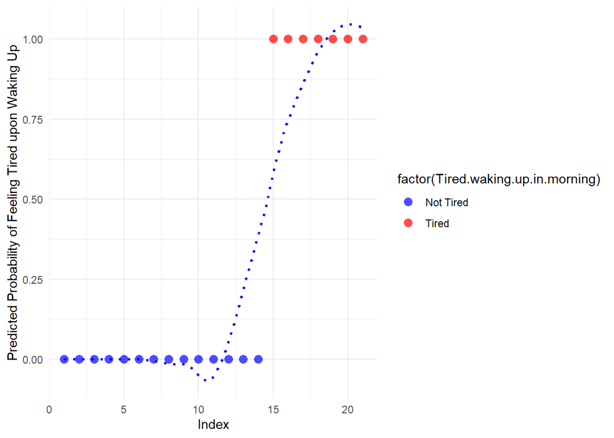

```r
library(ggplot2)

# Create predicted data frame
predicted.data <- data.frame(probability.of.hd = logistic$fitted.values,
                              Tired.waking.up.in.morning = data$Tired.waking.up.in.morning)
predicted.data <- predicted.data[order(predicted.data$probability.of.hd, decreasing = FALSE),]
predicted.data$rank <- 1:nrow(predicted.data)

# Plot using ggplot with a smooth line
ggplot(data = predicted.data, aes(x = rank, y = probability.of.hd)) +
  geom_point(aes(color = factor(Tired.waking.up.in.morning)), alpha = 0.7, shape = 16, size = 3) +  # Larger points for better visibility
  geom_smooth(method = "loess", se = FALSE, linetype = "dotted", color = "blue") +  # Add a smoothed line
  scale_color_manual(values = c("blue", "red"), labels = c("Not Tired", "Tired")) +  # Custom color scheme
  labs(x = "Index", y = "Predicted Probability of Feeling Tired upon Waking Up") +  # Custom axis labels
  theme_minimal() +  # Minimalist theme
  theme(legend.position = "right")  # Legend position
```

The plot is a graphical representation of a predictive model, depicting the probability of feeling tired upon waking up in the morning against an index. Blue dots labeled “Not Tired” represent lower probabilities, while red dots labeled “Tired” indicate higher probabilities. The model suggests a threshold around the index 15, where there’s a significant increase in the predicted probability of feeling tired. The dotted line likely represents a fitted curve, showing how the probability changes across different index values, with a steep incline around the threshold. This visualization could be used to understand factors influencing morning tiredness or evaluate a model predicting tiredness.

```r
# From Caret
pdata <- predict(logistic,newdata=data,type="response" )
pdata
```

```
##       masinl        peace        Patty        Bunny        tl868        drphy
## 2.220446e-16 2.220446e-16 2.220446e-16 2.220446e-16 1.000000e+00 2.220446e-16
##        trave        19!@s       yh2020       ds2134        ki567       ak2001
## 1.000000e+00 1.000000e+00 2.220446e-16 2.900701e-12 2.220446e-16 1.252410e-11
##       Harvey        hahah        AKIRA       vp1234        sss32      MVA37@S
## 1.000000e+00 1.642936e-09 2.220446e-16 1.000000e+00 1.053235e-09 1.000000e+00
##         2134        15801        Baiqi
## 3.147567e-09 1.804358e-10 1.000000e+00
```

```r
data$Tired.waking.up.in.morning
```

```
##  [1] 0 0 0 0 1 0 1 1 0 0 0 0 1 0 0 1 0 1 0 0 1
```

Q5: Accuracy

```r
pdataF <- as.factor(ifelse(test=as.numeric(pdata>0.5) == 0, yes="0", no="1"))
data$Tired.waking.up.in.morning <- factor(data$Tired.waking.up.in.morning, levels = c("0", "1"))
levels(pdataF) <- levels(data$Tired.waking.up.in.morning)
confusionMatrix(pdataF, data$Tired.waking.up.in.morning)
```

```
## Confusion Matrix and Statistics
##
##           Reference
## Prediction  0  1
##          0 14  0
##          1  0  7
##
##                Accuracy : 1
##                  95% CI : (0.8389, 1)
##     No Information Rate : 0.6667
##     P-Value [Acc > NIR] : 0.0002005
##
##                   Kappa : 1
##
##  Mcnemar's Test P-Value : NA
##
##             Sensitivity : 1.0000
##             Specificity : 1.0000
##          Pos Pred Value : 1.0000
##          Neg Pred Value : 1.0000
##              Prevalence : 0.6667
##          Detection Rate : 0.6667
##    Detection Prevalence : 0.6667
##       Balanced Accuracy : 1.0000
##
##        'Positive' Class : 0
##
```

The confusion matrix presents the classification results of a binary classifier. It shows that out of 21 instances, 14 were correctly classified as 0 and 7 as 1, yielding perfect accuracy of 1. The Kappa statistic also indicates perfect agreement beyond chance. Sensitivity, specificity, positive predictive value, and negative predictive value are all 1, indicating perfect performance in both identifying positive and negative cases. The balanced accuracy, which considers imbalanced class sizes, is also 1. Overall, the model demonstrates exceptional performance, accurately classifying all instances with high confidence.

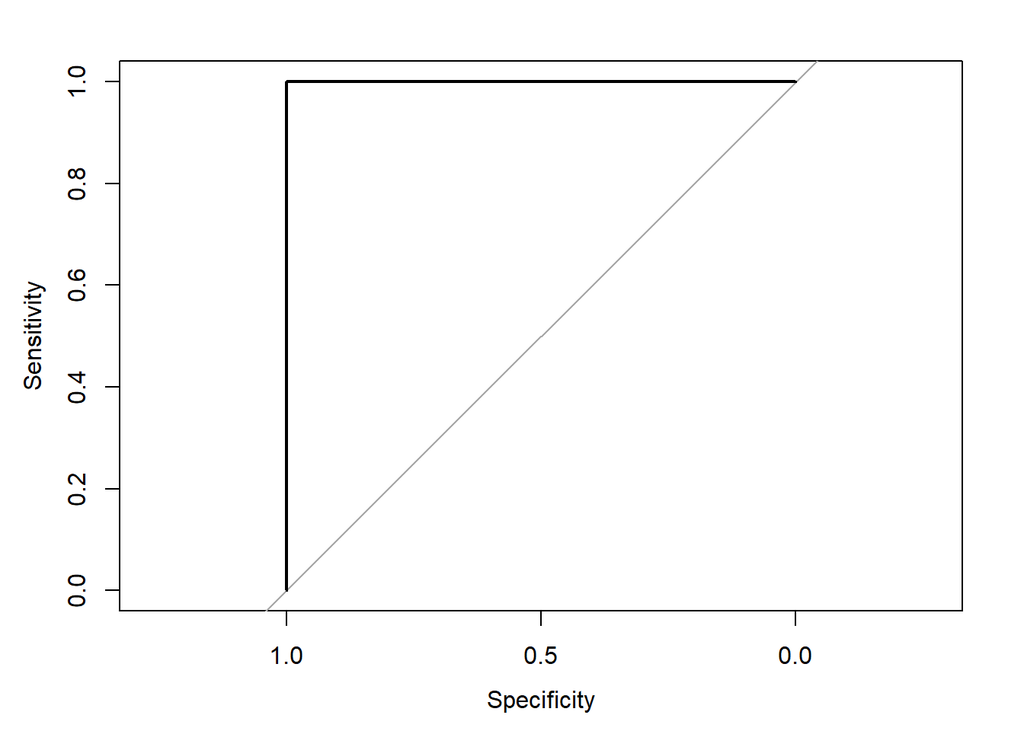

```
##
## Call:
## roc.default(response = data$Tired.waking.up.in.morning, predictor = logistic$fitted.values,     plot = TRUE)
##
## Data: logistic$fitted.values in 14 controls (data$Tired.waking.up.in.morning 0) < 7 cases (data$Tired.waking.up.in.morning 1).
## Area under the curve: 1
```

```r
roc(data$Tired.waking.up.in.morning, logistic$fitted.values, plot=TRUE)
```

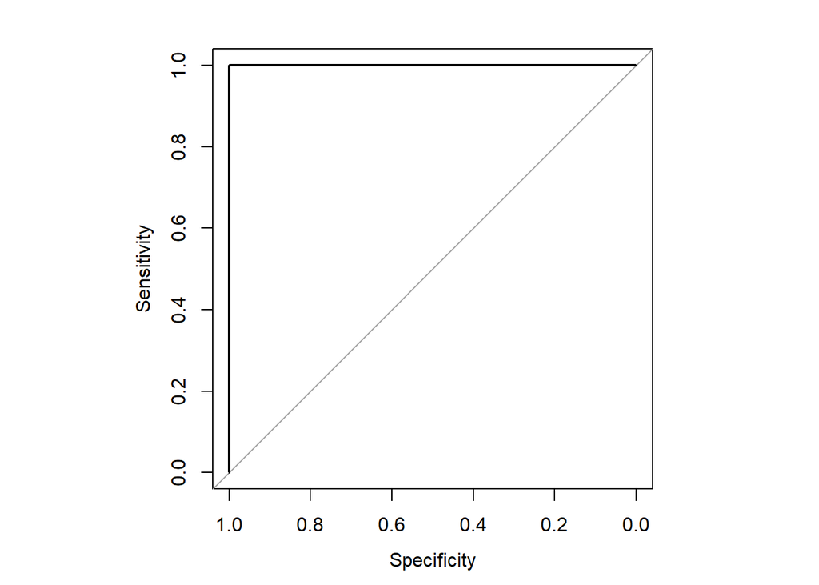

```
##
## Call:
## roc.default(response = data$Tired.waking.up.in.morning, predictor = logistic$fitted.values,     plot = TRUE)
##
## Data: logistic$fitted.values in 14 controls (data$Tired.waking.up.in.morning 0) < 7 cases (data$Tired.waking.up.in.morning 1).
## Area under the curve: 1
```

```r
par(pty = "s")
roc(data$Tired.waking.up.in.morning, logistic$fitted.values, plot=TRUE)
```

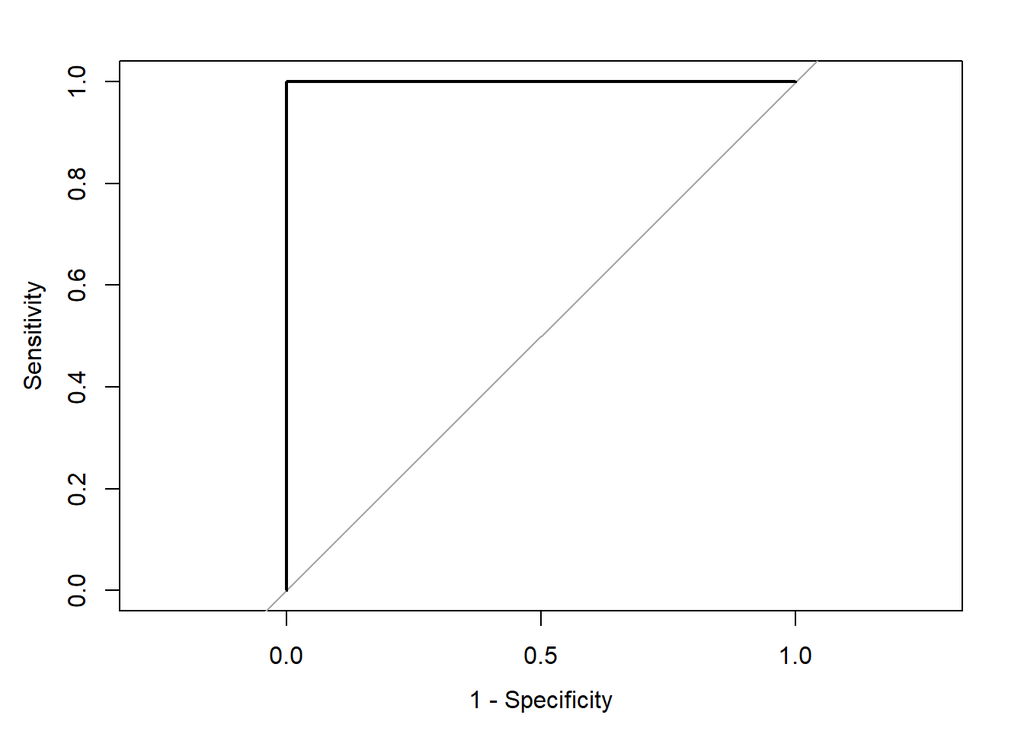

```
##
## Call:
## roc.default(response = data$Tired.waking.up.in.morning, predictor = logistic$fitted.values,     plot = TRUE, legacy.axes = TRUE)
##
## Data: logistic$fitted.values in 14 controls (data$Tired.waking.up.in.morning 0) < 7 cases (data$Tired.waking.up.in.morning 1).
## Area under the curve: 1
```

```r
roc(data$Tired.waking.up.in.morning, logistic$fitted.values, plot=TRUE, legacy.axes=TRUE)
```

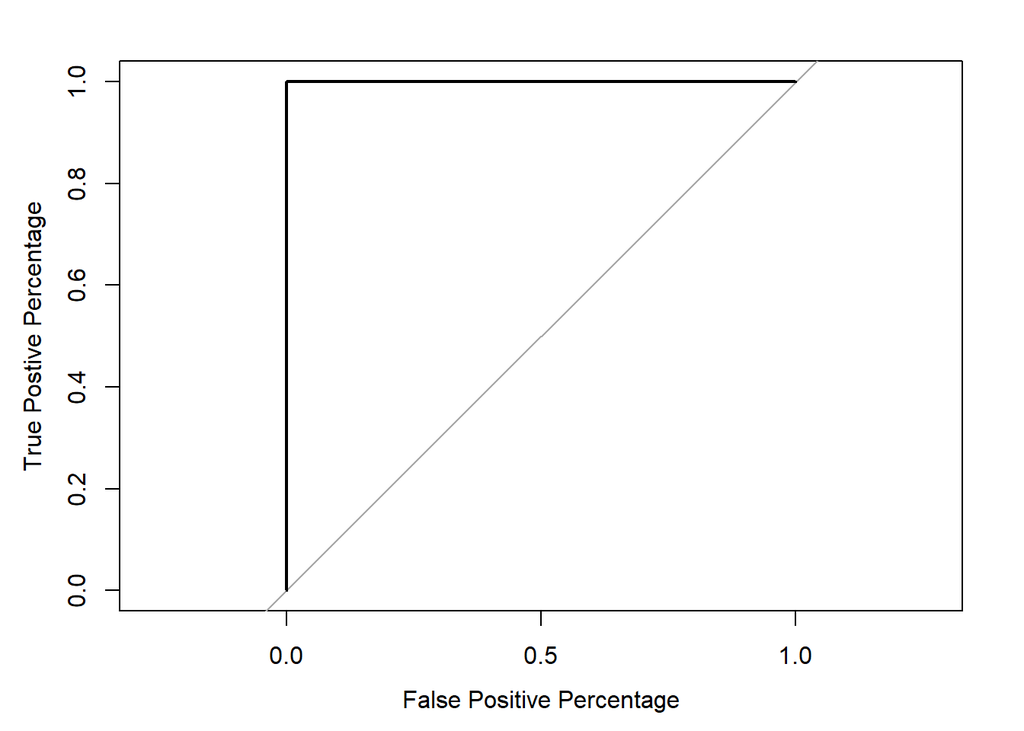

```
##
## Call:
## roc.default(response = data$Tired.waking.up.in.morning, predictor = logistic$fitted.values,     plot = TRUE, legacy.axes = TRUE, xlab = "False Positive Percentage",     ylab = "True Postive Percentage")
##
## Data: logistic$fitted.values in 14 controls (data$Tired.waking.up.in.morning 0) < 7 cases (data$Tired.waking.up.in.morning 1).
## Area under the curve: 1
```

```r
roc(data$Tired.waking.up.in.morning, logistic$fitted.values, plot=TRUE, legacy.axes=TRUE, xlab="False Positive Percentage", ylab="True Postive Percentage")
```

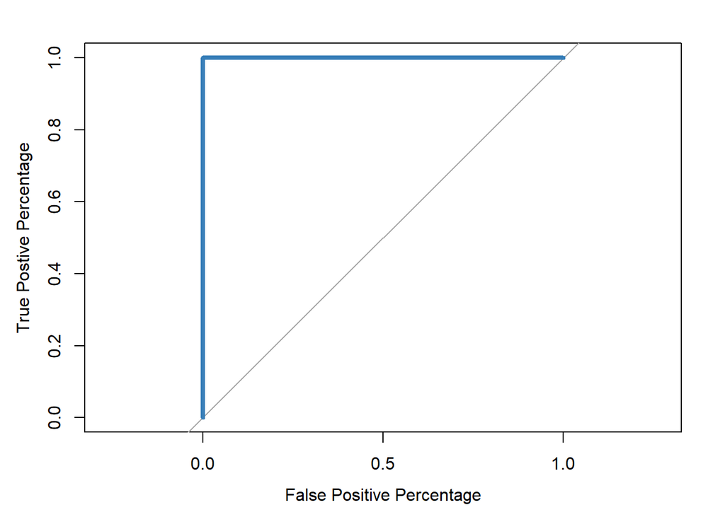

```
##
## Call:
## roc.default(response = data$Tired.waking.up.in.morning, predictor = logistic$fitted.values,     plot = TRUE, legacy.axes = TRUE, xlab = "False Positive Percentage",     ylab = "True Postive Percentage", col = "#377eb8", lwd = 4)
##
## Data: logistic$fitted.values in 14 controls (data$Tired.waking.up.in.morning 0) < 7 cases (data$Tired.waking.up.in.morning 1).
## Area under the curve: 1
```

```r
roc(data$Tired.waking.up.in.morning, logistic$fitted.values, plot=TRUE, legacy.axes=TRUE, xlab="False Positive Percentage", ylab="True Postive Percentage", col="#377eb8", lwd=4)
```

```r
roc.info <- roc(data$Tired.waking.up.in.morning, logistic$fitted.values, legacy.axes=TRUE)
str(roc.info)
```

```
## List of 15
##  $ percent           : logi FALSE
##  $ sensitivities     : num [1:13] 1 1 1 1 1 ...
##  $ specificities     : num [1:13] 0 0.571 0.643 0.714 0.786 ...
##  $ thresholds        : num [1:13] -Inf 1.45e-12 7.71e-12 9.65e-11 6.17e-10 ...
##  $ direction         : chr "<"
##  $ cases             : Named num [1:7] 1 1 1 1 1 ...
##   ..- attr(*, "names")= chr [1:7] "tl868" "trave" "19!@s" "Harvey" ...
##  $ controls          : Named num [1:14] 2.22e-16 2.22e-16 2.22e-16 2.22e-16 2.22e-16 ...
##   ..- attr(*, "names")= chr [1:14] "masinl" "peace" "Patty" "Bunny" ...
##  $ fun.sesp          :function (thresholds, controls, cases, direction)
##  $ auc               : 'auc' num 1
##   ..- attr(*, "partial.auc")= logi FALSE
##   ..- attr(*, "percent")= logi FALSE
##   ..- attr(*, "roc")=List of 15
##   .. ..$ percent           : logi FALSE
##   .. ..$ sensitivities     : num [1:13] 1 1 1 1 1 ...
##   .. ..$ specificities     : num [1:13] 0 0.571 0.643 0.714 0.786 ...
##   .. ..$ thresholds        : num [1:13] -Inf 1.45e-12 7.71e-12 9.65e-11 6.17e-10 ...
##   .. ..$ direction         : chr "<"
##   .. ..$ cases             : Named num [1:7] 1 1 1 1 1 ...
##   .. .. ..- attr(*, "names")= chr [1:7] "tl868" "trave" "19!@s" "Harvey" ...
##   .. ..$ controls          : Named num [1:14] 2.22e-16 2.22e-16 2.22e-16 2.22e-16 2.22e-16 ...
##   .. .. ..- attr(*, "names")= chr [1:14] "masinl" "peace" "Patty" "Bunny" ...
##   .. ..$ fun.sesp          :function (thresholds, controls, cases, direction)
##   .. ..$ auc               : 'auc' num 1
##   .. .. ..- attr(*, "partial.auc")= logi FALSE
##   .. .. ..- attr(*, "percent")= logi FALSE
##   .. .. ..- attr(*, "roc")=List of 8
##   .. .. .. ..$ percent      : logi FALSE
##   .. .. .. ..$ sensitivities: num [1:13] 1 1 1 1 1 ...
##   .. .. .. ..$ specificities: num [1:13] 0 0.571 0.643 0.714 0.786 ...
##   .. .. .. ..$ thresholds   : num [1:13] -Inf 1.45e-12 7.71e-12 9.65e-11 6.17e-10 ...
##   .. .. .. ..$ direction    : chr "<"
##   .. .. .. ..$ cases        : Named num [1:7] 1 1 1 1 1 ...
##   .. .. .. .. ..- attr(*, "names")= chr [1:7] "tl868" "trave" "19!@s" "Harvey" ...
##   .. .. .. ..$ controls     : Named num [1:14] 2.22e-16 2.22e-16 2.22e-16 2.22e-16 2.22e-16 ...
##   .. .. .. .. ..- attr(*, "names")= chr [1:14] "masinl" "peace" "Patty" "Bunny" ...
##   .. .. .. ..$ fun.sesp     :function (thresholds, controls, cases, direction)
##   .. .. .. ..- attr(*, "class")= chr "roc"
##   .. ..$ call              : language roc.default(response = data$Tired.waking.up.in.morning, predictor = logistic$fitted.values,      legacy.axes = TRUE)
##   .. ..$ original.predictor: Named num [1:21] 2.22e-16 2.22e-16 2.22e-16 2.22e-16 1.00 ...
##   .. .. ..- attr(*, "names")= chr [1:21] "masinl" "peace" "Patty" "Bunny" ...
##   .. ..$ original.response : Factor w/ 2 levels "0","1": 1 1 1 1 2 1 2 2 1 1 ...
##   .. ..$ predictor         : Named num [1:21] 2.22e-16 2.22e-16 2.22e-16 2.22e-16 1.00 ...
##   .. .. ..- attr(*, "names")= chr [1:21] "masinl" "peace" "Patty" "Bunny" ...
##   .. ..$ response          : Factor w/ 2 levels "0","1": 1 1 1 1 2 1 2 2 1 1 ...
##   .. ..$ levels            : chr [1:2] "0" "1"
##   .. ..- attr(*, "class")= chr "roc"
##  $ call              : language roc.default(response = data$Tired.waking.up.in.morning, predictor = logistic$fitted.values,      legacy.axes = TRUE)
##  $ original.predictor: Named num [1:21] 2.22e-16 2.22e-16 2.22e-16 2.22e-16 1.00 ...
##   ..- attr(*, "names")= chr [1:21] "masinl" "peace" "Patty" "Bunny" ...
##  $ original.response : Factor w/ 2 levels "0","1": 1 1 1 1 2 1 2 2 1 1 ...
##  $ predictor         : Named num [1:21] 2.22e-16 2.22e-16 2.22e-16 2.22e-16 1.00 ...
##   ..- attr(*, "names")= chr [1:21] "masinl" "peace" "Patty" "Bunny" ...
##  $ response          : Factor w/ 2 levels "0","1": 1 1 1 1 2 1 2 2 1 1 ...
##  $ levels            : chr [1:2] "0" "1"
##  - attr(*, "class")= chr "roc"
```

# tpp(true positive percentage) & fpp(false positive precentage)

```r
roc.df <- data.frame(tpp=roc.info$sensitivities*100, fpp=(1 - roc.info$specificities)*100, thresholds=roc.info$thresholds)
roc.df
```

```
##          tpp        fpp   thresholds
## 1  100.00000 100.000000         -Inf
## 2  100.00000  42.857143 1.450462e-12
## 3  100.00000  35.714286 7.712402e-12
## 4  100.00000  28.571429 9.647996e-11
## 5  100.00000  21.428571 6.168355e-10
## 6  100.00000  14.285714 1.348086e-09
## 7  100.00000   7.142857 2.395252e-09
## 8  100.00000   0.000000 5.000000e-01
## 9   85.71429   0.000000 1.000000e+00
## 10  71.42857   0.000000 1.000000e+00
## 11  57.14286   0.000000 1.000000e+00
## 12  42.85714   0.000000 1.000000e+00
## 13   0.00000   0.000000          Inf
```

```r
head(roc.df)
```

```
##   tpp       fpp   thresholds
## 1 100 100.00000         -Inf
## 2 100  42.85714 1.450462e-12
## 3 100  35.71429 7.712402e-12
## 4 100  28.57143 9.647996e-11
## 5 100  21.42857 6.168355e-10
## 6 100  14.28571 1.348086e-09
```

```r
tail(roc.df)
```

```
##          tpp fpp thresholds
## 8  100.00000   0        0.5
## 9   85.71429   0        1.0
## 10  71.42857   0        1.0
## 11  57.14286   0        1.0
## 12  42.85714   0        1.0
## 13   0.00000   0        Inf
```

```r
roc.df[roc.df$tpp > 60 & roc.df$tpp < 80,]
```

```
##         tpp fpp thresholds
## 10 71.42857   0          1
```

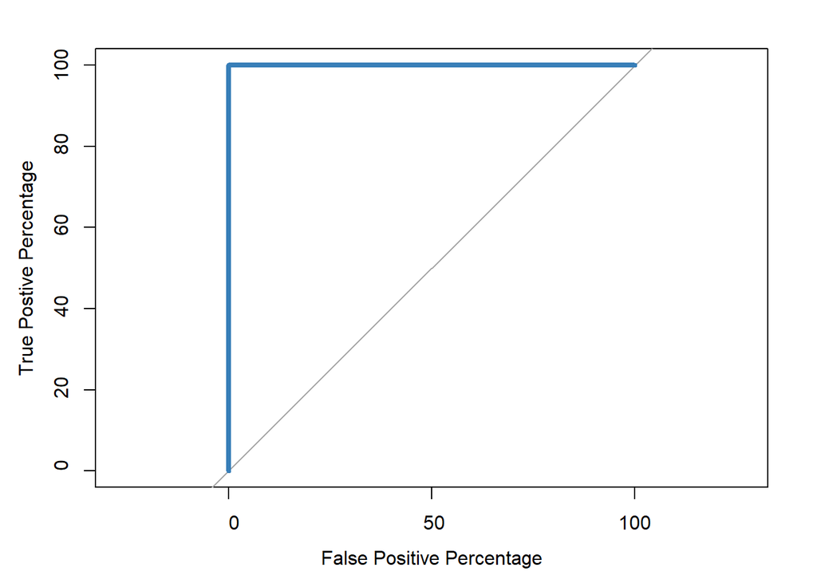

```
##
## Call:
## roc.default(response = data$Tired.waking.up.in.morning, predictor = logistic$fitted.values,     percent = TRUE, plot = TRUE, legacy.axes = TRUE, xlab = "False Positive Percentage",     ylab = "True Postive Percentage", col = "#377eb8", lwd = 4)
##
## Data: logistic$fitted.values in 14 controls (data$Tired.waking.up.in.morning 0) < 7 cases (data$Tired.waking.up.in.morning 1).
## Area under the curve: 100%
```

```r
roc(data$Tired.waking.up.in.morning, logistic$fitted.values, plot=TRUE, legacy.axes=TRUE, xlab="False Positive Percentage", ylab="True Postive Percentage", col="#377eb8", lwd=4, percent=TRUE)
```

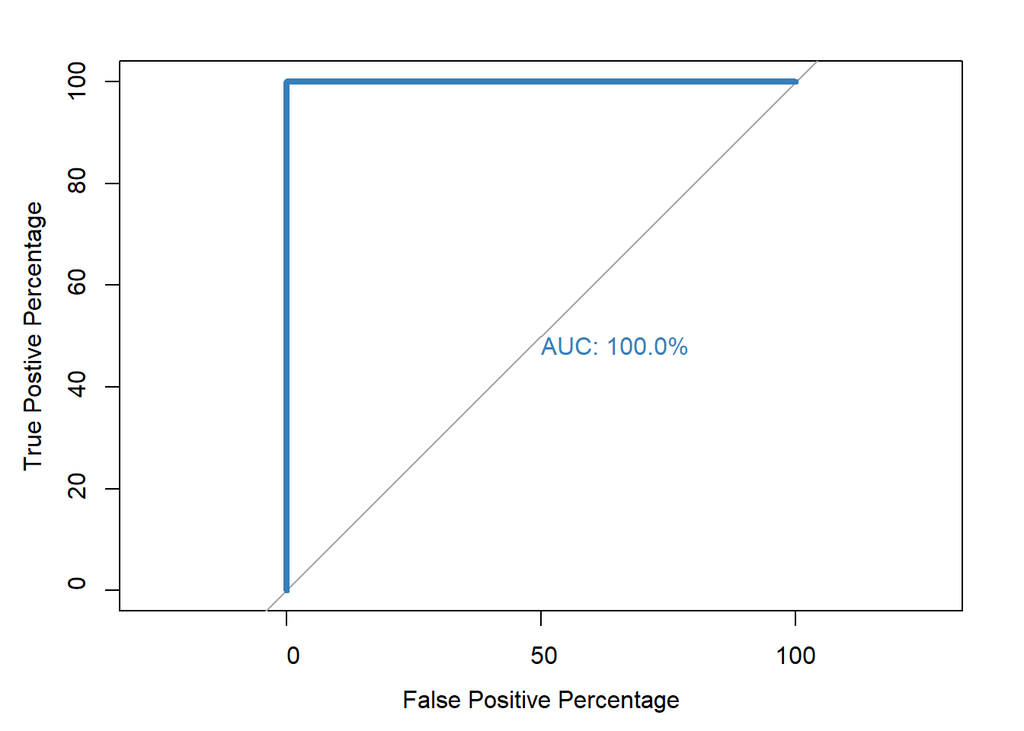

```
##
## Call:
## roc.default(response = data$Tired.waking.up.in.morning, predictor = logistic$fitted.values,     percent = TRUE, plot = TRUE, legacy.axes = TRUE, xlab = "False Positive Percentage",     ylab = "True Postive Percentage", col = "#377eb8", lwd = 4,     print.auc = TRUE)
##
## Data: logistic$fitted.values in 14 controls (data$Tired.waking.up.in.morning 0) < 7 cases (data$Tired.waking.up.in.morning 1).
## Area under the curve: 100%
```

```r
roc(data$Tired.waking.up.in.morning, logistic$fitted.values, plot=TRUE, legacy.axes=TRUE, xlab="False Positive Percentage", ylab="True Postive Percentage", col="#377eb8", lwd=4, percent=TRUE, print.auc=TRUE)
```

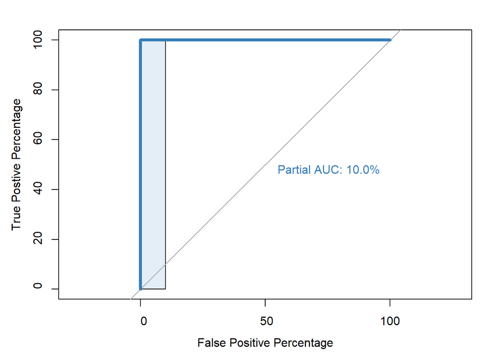

```
##
## Call:
## roc.default(response = data$Tired.waking.up.in.morning, predictor = logistic$fitted.values,     percent = TRUE, plot = TRUE, legacy.axes = TRUE, xlab = "False Positive Percentage",     ylab = "True Postive Percentage", col = "#377eb8", lwd = 4,     print.auc = TRUE, partial.auc = c(100, 90), auc.…
##
## Data: logistic$fitted.values in 14 controls (data$Tired.waking.up.in.morning 0) < 7 cases (data$Tired.waking.up.in.morning 1).
## Partial area under the curve (specificity 100%-90%): 10%
```

```r
roc(data$Tired.waking.up.in.morning, logistic$fitted.values, plot=TRUE, legacy.axes=TRUE, xlab="False Positive Percentage", ylab="True Postive Percentage", col="#377eb8", lwd=4, percent=TRUE, print.auc=TRUE, partial.auc=c(100, 90), auc.polygon = TRUE, auc.polygon.col = "#377eb822", print.auc.x=45)
```

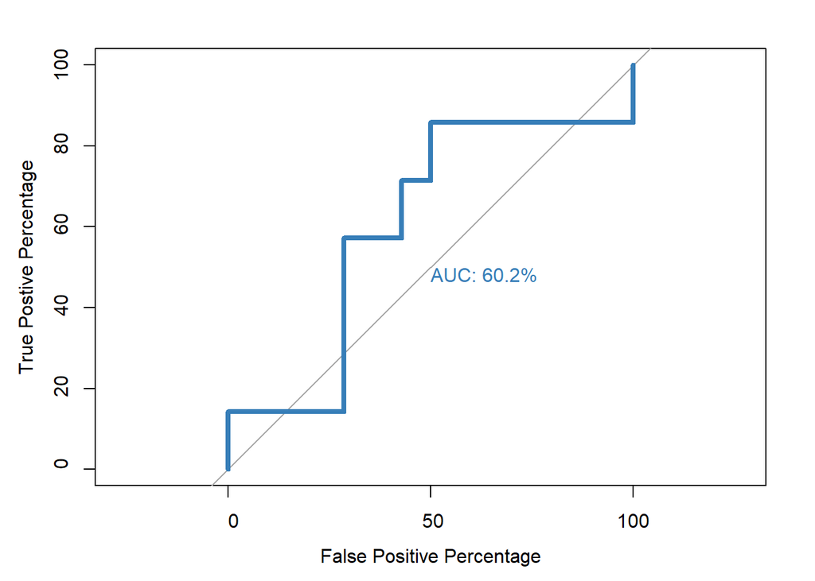

```
##
## Call:
## roc.default(response = data$Tired.waking.up.in.morning, predictor = logistic_simple$fitted.values,     percent = TRUE, plot = TRUE, legacy.axes = TRUE, xlab = "False Positive Percentage",     ylab = "True Postive Percentage", col = "#377eb8", lwd = 4,     print.auc = TRUE)
##
## Data: logistic_simple$fitted.values in 14 controls (data$Tired.waking.up.in.morning 0) < 7 cases (data$Tired.waking.up.in.morning 1).
## Area under the curve: 60.2%
```

```r
# Lets do two roc plots to understand which model is better
roc(data$Tired.waking.up.in.morning, logistic_simple$fitted.values, plot=TRUE, legacy.axes=TRUE, percent=TRUE, xlab="False Positive Percentage", ylab="True Postive Percentage", col="#377eb8", lwd=4, print.auc=TRUE)
```

[output not shown]